# Coursework Report

*N* removed NAs: 3

*N* removed typo: 1

*N* removed <18: 25

*N* total clean: 121

| Group | *N* | *M*<sub>age</sub> | *M*<sub>rating</sub> |
| --- | --- | --- | --- |
| Control | 62 | 20.97 | 6.6 |
| Experim | 59 | 20.66 | 5.4 |

**Main analysis results**

*t*(119) = 9.19, *p* < .001

[interactive chart not shown]

[figure not shown]

[interactive chart not shown]

# Coursework Report

Analysing Data, Spring 2020

# Methods

## Design

This study tests the motion that the colour red, increases a women’s perceived attraction towards a man. In more detail, the colours red (“experimental condition”) and white (“control condition”) were selected as the background of a black-and-white photo of a man. Female participants, in an independent measures design, rated the perceived attractiveness of the man. The number of female participants and age breakdown by condition is given in Table 1. A rating system was used which consisted of three face-valid statements: “How attractive do you think this person is?” and “How pleasant is this person to look at? and”If I were to meet the person in their picture face to face, I would think he is attractive”. Participants answered using a rating scale which ranged from 1 (not at all attractive) to 9 (extremely attractive). This experiment tests the hypothesis that the picture of a man with a red background will produce, on average, a higher attractiveness rating compared to the picture with a white background. To test the significance of the means produced by both experimental conditions, a t-test was executed.

Table 1 *Descriptive statistics by Condition*

[output not shown]

# Results

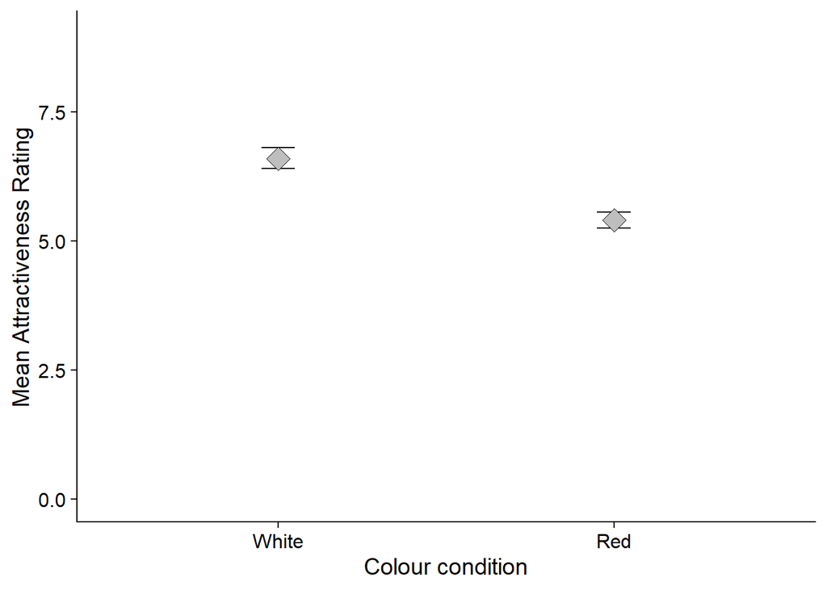

**Figure. 1 Mean Attractiveness Rating to Colour condition**

Table 2 *Mean Attractiveness Ratings*

| Colour Condition | *M*<sub>Attractiveness</sub> | *SD*<sub>Attractiveness</sub> |
| --- | --- | --- |
| White | 6.6 | 0.82 |
| Red | 5.4 | 0.59 |

# Discussion

As a whole, the results of this experiment does not provide strong support towards the hypothesis that colour, specifically red, increases a woman’s perceived attractiveness towards men. The findings of this study illustrate that the colour white, which was used as a neutral colour, evoked a higher perceived attractiveness towards men than the colour red.

Compared to the original study, carried out by Elliot et al. (2010), different results were concluded as their findings provided “strong support for the hypothesized red effect” (Elliot et al., 2010, p.12). Elliot et al. (2010) found a strong influence between the colour red and a women’s perceptions of the attractiveness of men compared to the colour white. The difference in findings between the present study and the Elliot et al. (2010) study, could be used to further support the motion, proposed by Francis (2013), that the Elliot el al. (2010) paper should be regarded as ‘non-scientific’ due to statistical analysis issues.

Moreover, research conducted by Peperkoorn, Roberts and Pollet (2016), also found insufficient evidence supporting the relationship between the red effect and perceived attractiveness throughout the three experiments they conducted. This was further supported by Hesslinger and Goldbach (2015) who replicated the Elliot et al. study whilst enhancing its ecological validity and also discovered no significant impact of red towards perceived attractiveness. As the present research came to similar conclusions, this signifies that the Elliot et al.(2010) study contains poor internal validity and therefore our hypothesis, which was based off of the Elliot el al. study, is not supported.

The current study contains limitations, some of which are shared in the study replicated (Elliot et al., 2010). The three face-valid statements and a rating scale used makes it unable to measure true perceived attractiveness as the statements presented are vague and the rating scale is simplistic. Further research can use more reliable methods to measure attractiveness such as measuring biological processes such as the hormones adrenaline and dopamine which both have been associated with physical attraction (McKinney, 2011, Fisher Ph.D., 2013). Using these innate processes to measure attractiveness will increase the validity of the study compared to using questionnaires where the participants are susceptible to lie or not fully understand the statements.

Furthermore, the use of an experimental lab setting decreases the ecological validity of the study, as it is harder to generalise the findings to real-life situations. Future studies may produce an experiment promoting more mundane realism in their settings such as using online dating profiles (Fiore, Taylor, Mendelsohn & Hearst, 2008), to deter participants from demand characteristics and to produce more generalizable results.

Additionally, the use of an independent measures design makes the data susceptible to participant variables which in this case may be specific male preferences. As the current study only used one photographed male, this decreased the chances of higher perceived attractiveness due to preferences. Participant preference acts as a confounding variable which diminishes the effect of our independent variable (colour) and in turn produces unreliable results. Future replications of this study may produce a pre questionnaire to obtain information about participant attraction preference and divide them into similar preference groups. Furthermore, a larger range of diverse males should be presented to fit these preferences.

As a whole, future research should focus on improving methodological issues to ensure high internal validity within the experiment and grasp a clear conclusion towards whether red increases perceived attractiveness towards men. Moreover, research should include different sexual orientations instead of focusing on heterosexual behaviour (Elliot et al., 2010). Therefore, results will be more generalizable and clear as to if the colour red makes anyone more attractive or just one type of gender or sexual orientation.

In summary, our results do not support our hypothesis: red increases a woman’s perceived attractiveness towards a man. The current study found that white (neutral colour), increased perceived attractiveness towards men compared to the colour red, which contradicts with the findings of the replicated study by Elliott (2010). Methodological issues were investigated as limitations within the present study. Additionally, future research should examine whether people with different sexual orientations are attracted to their sexual preferences when paired with a colour. As a whole, this study illustrates that the colour red does not make men more attractive however, future research can be implemented to further investigate this claim.

# References

Elliot, A. J., Niesta Kayser, D., Greitemeyer, T., Lichtenfeld, S., Gramzow, R. H., Maier, M. A., & Liu, H. (2010). Red, rank, and romance in women viewing men. *Journal of Experimental Psychology: General, 139*(3), 399.

Fiore, A., Taylor, L., Mendelsohn, G., & Hearst, M. (2008). Assessing attractiveness in online dating profiles. *Proceeding Of The Twenty-Sixth Annual CHI Conference On Human Factors In Computing Systems - CHI ’08.*doi: 10.1145/1357054.1357181

Fisher Ph.D, M. (2013). The Science Behind Falling in Love. Retrieved from: https://www.psychologytoday.com/gb/blog/loves-evolver/201302/the-science-behind-falling-in-love

Francis, G. (2013). Publication bias in “Red, rank, and romance in women viewing men,” by Elliot et al. (2010). *Journal Of Experimental Psychology: General, 142*(1), 292-296.

Hesslinger, V., Goldbach, L., & Carbon, C. (2015). Men in red: A reexamination of the red-attractiveness effect. *Psychonomic Bulletin & Review, 22*(4), 1142-1148.

McKinney, K. (2011). The effects of Adrenaline on Arousal and Attraction. Retrieved from: http://www.mckendree.edu/academics/scholars/issue17/mckinney.htm

Peperkoorn, L., Roberts, S., & Pollet, T. (2016). Revisiting the Red Effect on Attractiveness and Sexual Receptivity. *Evolutionary Psychology*14(4), 147470491667384.